# ggplot2 Practice

Lizzie Kumar and Em Beauchamp

### BYOPlot

Choose a built-in dataset of interest (e.g. `diamonds`, `mtcars`, `CO2`, `quakes`) and construct plots using the following geoms (or others we haven’t seen!) to reveal an interesting relationship.

- `geom_smooth`
- `geom_histogram`
- `geom_density`
- `geom_boxplot`

You will be presenting one of these plots to the group.

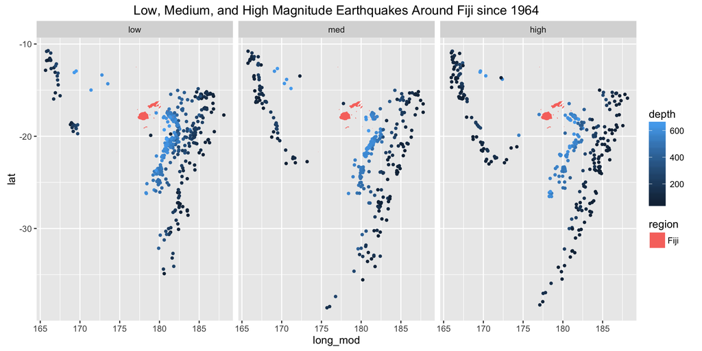

```r
world_map <- map_data("world")
fiji <- filter(world_map, region == "Fiji") %>%
  mutate(long_mod = long %% 360)

# calculate 3 quantiles for magnitude
q3 <- quantile(quakes$mag, probs = seq(0, 1, .3333333333), na.rm = TRUE)

quake_new <- quakes %>%
  mutate(disc_mag = ifelse((mag <= q3[2]), "low",
                           ifelse((mag > q3[2] & mag <= q3[3]), "med",
                                  "high"))) %>%
  mutate(disc_mag = factor(disc_mag,
                           levels = c("low", "med", "high"))) %>%
  mutate(long_mod = long %% 360)

ggplot() +
  geom_point(data = quake_new, aes(x = long_mod, y = lat, color = depth),
             size = 1) +
  geom_polygon(data = fiji, aes(x = long_mod, y = lat, group=group,
                                fill = region), show.legend = TRUE) +
  facet_wrap(~disc_mag) +
  ggtitle("Low, Medium, and High Magnitude Earthquakes Around Fiji since 1964")
```

```r
summary(quake_new$disc_mag)
```

```
##  low  med high
##  377  306  317
```

## Flights

1. The plot below displays the relationship between the mean arrival delay and the mean distance travelled by every plane in the data set. It also shows the total number of flights made by each plane by the size of the plotted circle. Please form a single chain that will create this plot, starting with the raw data set. You will also want to exclude the edge cases from your analysis, so focus on the planes that have logged more than 20 flights and flown an average distance of less than 2000 miles.

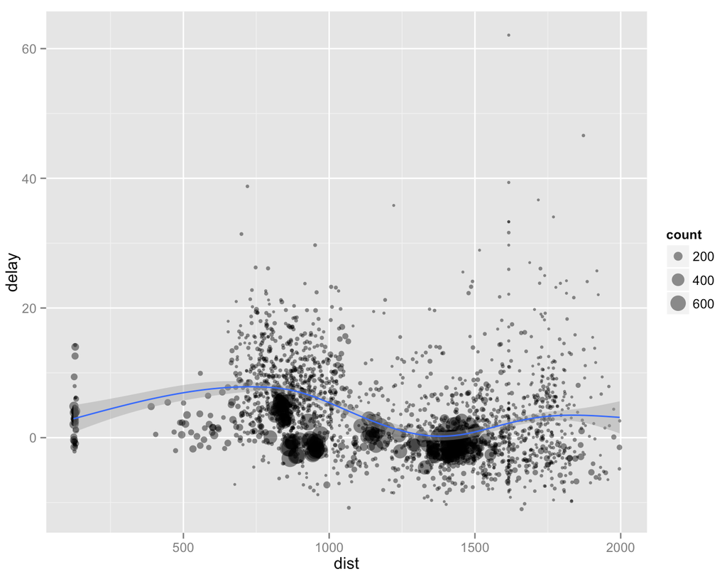

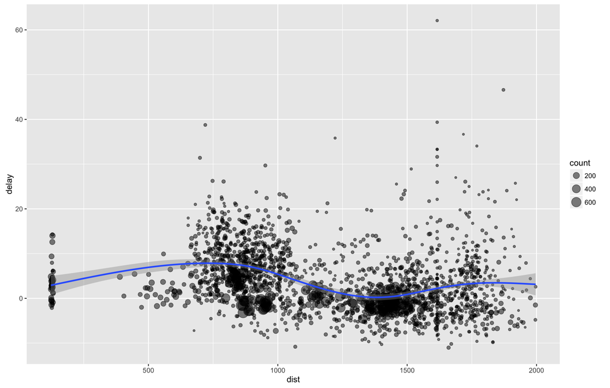

```r
flights %>%
  select(tailnum, arr_delay, distance) %>%
  group_by(tailnum) %>%
  summarize(delay = mean(arr_delay, na.rm = TRUE),
            dist = mean(distance, na.rm = TRUE),
            count = n()) %>%
  filter(count > 20, dist < 2000, tailnum != "") %>%
  ggplot(aes(x = dist, y = delay)) +
    geom_point(aes(size = count), alpha=0.5) +
    geom_smooth()
```

1. There are two plots that show up in the `dplyr` slides. How could these be improved to make them easier to read/interpret? Please implement these improvements.

### One last time…Global Warming!

Rebuild the plots that you generated according to exercises 4 and 9 using the dataframe you previously contructed, `dplyr`, and `ggplot2`. Recycle dataframes and plots whereever you can.

```r
faren_data <- (tData/100 + 14)*1.8 + 32

data_matrix <- matrix(data = faren_data, nrow = length(faren_data)/12, ncol = 12, byrow = TRUE)

# Set column names
colnames(data_matrix) <- c("January", "February", "March", "April", "May",
                           "June", "July", "August", "September", "October",
                           "November", "December")
rownames(data_matrix) <- 1881:2012

tdata.df <- as.data.frame(as.table(data_matrix), stringsAsFactors = FALSE)

temp_data <- tdata.df %>%
  transmute(Temperature = Freq, Month = as.factor(Var2),
            Year = as.numeric(Var1)) %>%
  arrange(Year)
```

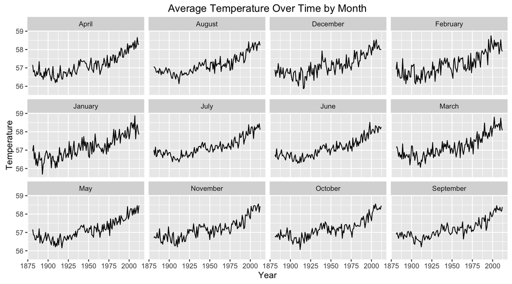

```r
ggplot(data = temp_data, aes(x = Year, y = Temperature)) +
  facet_wrap(~ Month) +
  geom_line() +
  ggtitle("Average Temperature Over Time by Month")
```

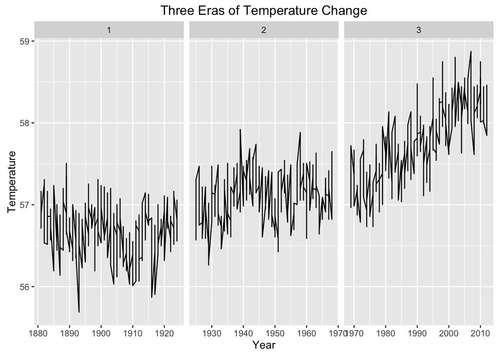

```r
temp_data %>%
  mutate(era = ifelse((Year %in% 1881:(1881+43)), 1,
                      ifelse((Year %in% 1925: (1925 + 43) ), 2, 3))) %>%
  ggplot(aes(x = Year, y = Temperature)) +
  geom_line() +
  facet_wrap(~era, scale = "free_x") +
  ggtitle("Three Eras of Temperature Change")
```